# AP Saint Louis

Lidia Delrieu

02/10/2020

#1. Data Management

```r
ap<-read.csv2("C:/Users/lidia/GitHub/databases/core/18_ap_saint_louis/data/ap_sept2020.csv")
```

#2. Analyse descriptive des variables ##2.1 Tableaux des caractéristiques à l’inclusion de toute la base

```r
dfSummary(ap2)
```

### Tableau-synthèse

#### ap2

**Dimensions:** 213 x 33  
**Doublons:** 0

| Variable | Stats / valeurs | Fréq. (% de valide) | Diagramme | Manquant |
| --- | --- | --- | --- | --- |
| id [integer] | Moy (é-t) : 107 (61.6) min < med < max: 1 < 107 < 213 ÉIQ (CV) : 106 (0.6) | 213 valeurs uniques (Séquence d’entiers) | : : : : : : : : : : : : : : : : : : : : : : : : : : : : : : : : : : : : : : : : : : : : : : : : : : | 0 (0%) |
| nom [character] | 1. Attali 2. Berthelot 3. Abada 4. Abe 5. achache 6. Agbahi 7. Agier 8. Algadafe 9. Allard· 10. Aloui [ 201 autres ] | 2 ( 0.9%) 2 ( 0.9%) 1 ( 0.5%) 1 ( 0.5%) 1 ( 0.5%) 1 ( 0.5%) 1 ( 0.5%) 1 ( 0.5%) 1 ( 0.5%) 1 ( 0.5%) 201 (94.4%) | IIIIIIIIIIIIIIIIII | 0 (0%) |
| prenom [character] | 1. Sophie 2. Patricia 3. Anne 4. Catherine 5. Christine 6. Dominique 7. Evelyne 8. isabelle 9. Marie 10. Nicole [ 156 autres ] | 6 ( 2.8%) 4 ( 1.9%) 3 ( 1.4%) 3 ( 1.4%) 3 ( 1.4%) 3 ( 1.4%) 3 ( 1.4%) 3 ( 1.4%) 3 ( 1.4%) 3 ( 1.4%) 179 (84.0%) | IIIIIIIIIIIIIIII | 0 (0%) |
| ddn [Date] | min : 1931-05-16 med : 1962-02-05 max : 1990-12-20 range : 59y 7m 4d | 213 valeurs uniques | : : . : : : : : : : : : : : : : : : . : : : : : : : : | 0 (0%) |
| date_diag [Date] | min : 2011-11-14 med : 2015-07-10 max : 2020-06-09 range : 8y 6m 26d | 202 valeurs uniques | : : : . : : : : : : : . : : : : : : : : : . | 0 (0%) |
| situ_inf [character] | 1. (Chaîne vide) 2. rec loc | 212 (99.5%) 1 ( 0.5%) | IIIIIIIIIIIIIIIIIII | 0 (0%) |
| chir [factor] | 1. Non 2. Oui | 0 ( 0.0%) 109 (100.0%) | IIIIIIIIIIIIIIIIIIII | 104 (48.83%) |
| date_chir [Date] | min : 0213-07-24 med : 2016-04-15 max : 2018-02-22 range : 1804y 6m 29d | 100 valeurs uniques | : : : : : | 106 (49.77%) |
| type_chir [factor] | 1. In situ 2. Infiltrant | Aucune donnée valide |  | 213 (100%) |
| chir_gg [factor] | 1. Non 2. Oui | Aucune donnée valide |  | 213 (100%) |
| chimio [integer] | Min : 0 Moy : 0.9 Max : 1 | 0 : 22 (10.3%) 1 : 191 (89.7%) | II IIIIIIIIIIIIIIIII | 0 (0%) |
| type_chimio [factor] | 1. neoadj 2. adj | 43 (22.5%) 148 (77.5%) | IIII IIIIIIIIIIIIIII | 22 (10.33%) |
| proto [character] | 1. (Chaîne vide) 2. TXT | 212 (99.5%) 1 ( 0.5%) | IIIIIIIIIIIIIIIIIII | 0 (0%) |
| debut_ctp [character] | 1. (Chaîne vide) 2. 05/09/2013 | 212 (99.5%) 1 ( 0.5%) | IIIIIIIIIIIIIIIIIII | 0 (0%) |
| date_inscription [Date] | min : 2014-01-21 med : 2016-08-24 max : 2018-04-03 range : 4y 2m 13d | 111 valeurs uniques | : . : . . : . . : : : . : : : : . : : : : : : : : | 85 (39.91%) |
| escrime [factor] | 1. Non 2. Oui | 77 (61.1%) 49 (38.9%) | IIIIIIIIIIII IIIIIII | 87 (40.85%) |
| tennis [factor] | 1. Non 2. Oui | 87 (68.0%) 41 (32.0%) | IIIIIIIIIIIII IIIIII | 85 (39.91%) |
| yoga [factor] | 1. Non 2. Oui | 45 (33.8%) 88 (66.2%) | IIIIII IIIIIIIIIIIII | 80 (37.56%) |
| marche_nord [factor] | 1. Non 2. Oui | 73 (53.7%) 63 (46.3%) | IIIIIIIIII IIIIIIIII | 77 (36.15%) |
| q1 [character] | 1. (Chaîne vide) 2. 0 3. 1 4. en attente 5. incomplet | 94 (44.1%) 1 ( 0.5%) 115 (54.0%) 2 ( 0.9%) 1 ( 0.5%) | IIIIIIII IIIIIIIIII | 0 (0%) |
| date_kine1 [character] | 1. (Chaîne vide) 2. , 3. 0 4. 1 5. 24/09/2014 6. 24/10/2014 7. chant 8. demandée 9. faite) | 156 (73.2%) 1 ( 0.5%) 28 (13.2%) 13 ( 6.1%) 1 ( 0.5%) 1 ( 0.5%) 9 ( 4.2%) 3 ( 1.4%) 1 ( 0.5%) | IIIIIIIIIIIIII II I | 0 (0%) |
| q2 [character] | 1. (Chaîne vide) 2. 1 3. 520998 4. à refaire: reconvoquer fi | 210 (98.6%) 1 ( 0.5%) 1 ( 0.5%) 1 ( 0.5%) | IIIIIIIIIIIIIIIIIII | 0 (0%) |
| date_kine2 [logical] | Aucune donnée valide |  |  | 213 (100%) |
| presence [logical] | Aucune donnée valide |  |  | 213 (100%) |
| assiduite [integer] | 1 valeur unique | 1 : 1 (100.0%) | IIIIIIIIIIIIIIIIIIII | 212 (99.53%) |
| sport_pratique [integer] | 1 valeur unique | 13 : 1 (100.0%) | IIIIIIIIIIIIIIIIIIII | 212 (99.53%) |
| medecin [character] | 1. cuvier 2. giacchetti 3. teixeira 4. espie 5. bourstyn 6. charveriat 7. hocini 8. becourt 9. (Chaîne vide) 10. kloos [ 10 autres ] | 106 (49.8%) 34 (16.0%) 15 ( 7.0%) 13 ( 6.1%) 11 ( 5.2%) 7 ( 3.3%) 6 ( 2.8%) 4 ( 1.9%) 3 ( 1.4%) 2 ( 0.9%) 12 ( 5.6%) | IIIIIIIII III I I I I | 0 (0%) |
| recidive [factor] | 1. Non 2. Oui | 194 (91.1%) 19 ( 8.9%) | IIIIIIIIIIIIIIIIII I | 0 (0%) |
| date_recidive [character] | 1. (Chaîne vide) 2. 15/01/2019 3. 02/09/2016 4. 08/01/2015 5. 10/12/2018 6. 12/04/2019 7. 12/11/2016 8. 14/05/2017 9. 15/04/2019 10. 15/05/2016 [ 9 autres ] | 194 (91.1%) 2 ( 0.9%) 1 ( 0.5%) 1 ( 0.5%) 1 ( 0.5%) 1 ( 0.5%) 1 ( 0.5%) 1 ( 0.5%) 1 ( 0.5%) 1 ( 0.5%) 9 ( 4.2%) | IIIIIIIIIIIIIIIIII | 0 (0%) |
| statut [factor] | 1. Vivant 2. Décédé | 203 (95.3%) 10 ( 4.7%) | IIIIIIIIIIIIIIIIIII | 0 (0%) |
| date_dc [character] | 1. (Chaîne vide) 2. 02/11/2019 3. 05/08/2019 4. 06/07/2020 5. 09/01/2020 6. 10/08/2017 7. 12/08/2017 8. 16/08/2017 9. 20/05/2016 10. 27/11/2016 | 204 (95.8%) 1 ( 0.5%) 1 ( 0.5%) 1 ( 0.5%) 1 ( 0.5%) 1 ( 0.5%) 1 ( 0.5%) 1 ( 0.5%) 1 ( 0.5%) 1 ( 0.5%) | IIIIIIIIIIIIIIIIIII | 0 (0%) |
| date_derniere_nouvelles [Date] | min : 2015-08-31 med : 2020-07-06 max : 2020-12-27 range : 5y 3m 27d | 113 valeurs uniques | : : . : : : : : : | 0 (0%) |
| age [numeric] | Moy (é-t) : 53.2 (11.4) min < med < max: 26 < 52.4 < 81.7 ÉIQ (CV) : 16.6 (0.2) | 212 valeurs uniques | : . . : : : : . : : : : : . : : : : : : : : : : : : : : : . | 0 (0%) |

```r
view(dfSummary(ap2))
#descr(ap2, style = "rmarkdown")
```

1. Caractéristiques socio-démographiques Il y a 213 patientes dans la base avec un âge moyen au diagnostic de 53.2 ans (SD=11.4) et min=26 et max=81.7 ans (Je pourrais calculer plus l’âge moyen à l’inscription du programme)
2. Caractéristiques cliniques Le diagnostic de cancer du sein le plus ancien de la base remonte au 14 novembre 2011 et la plus récente au 09 juin 2020 avec une date médiane au diagnostic au 10 juillet 2015.

Traitements -n=191 (89.7%) patientes ont eu de la chimiothérapie dont 43 (22.5%) en néoadj et 148 (77.5%) en adjuvant

Avec les données disponibles la majorité des patientes semblent plutôt s’orienter vers le yoga n=88 (66.2%)

3. statut vital Au total sur les 213 participantes, 203 (95.3%) sont encore vivantes et 10 (4.7%) sont décédées dont n=7 qui ont reçu un traitement néoadj et n=3 qui ont reçu un traitement adjuvant

| Variable | Overall |
| --- | --- |
| Chimiothérapie reçue |  |
| Count | 213 |
| (%) |  |
| Non | 22 (10.33%) |
| Oui | 191 (89.67%) |
| Missing | 0 |

#2.2 Caractéristiques des patientes néo adj

43 patientes ont reçu de la chimiothérapie néoadjuvante et la moyenne d’âge des femmes est de 47.21 ans (SD=9.88) et min=28.57 et max=70.19 ans

##2.3 Caractéristiques des patientes adjuvantes ### Tableau-synthèse  
#### adj  
**Dimensions:** 148 x 33  
**Doublons:** 0

| Variable | Stats / valeurs | Fréq. (% de valide) | Diagramme | Manquant |
| --- | --- | --- | --- | --- |
| id [integer] | Moy (é-t) : 107.2 (60.6) min < med < max: 1 < 112.5 < 213 ÉIQ (CV) : 105.8 (0.6) | 148 valeurs uniques | . : : : : : : : : : : : : : : : : : : : : : : : : : : : : : : : : : : : : : | 0 (0%) |
| nom [character] | 1. Abada 2. Agbahi 3. Agier 4. Algadafe 5. Allard· 6. Aloui 7. Alpha 8. Amato 9. ambroise· 10. Andriamady [ 138 autres ] | 1 ( 0.7%) 1 ( 0.7%) 1 ( 0.7%) 1 ( 0.7%) 1 ( 0.7%) 1 ( 0.7%) 1 ( 0.7%) 1 ( 0.7%) 1 ( 0.7%) 1 ( 0.7%) 138 (93.2%) | IIIIIIIIIIIIIIIIII | 0 (0%) |
| prenom [character] | 1. Catherine 2. Christine 3. Dominique 4. isabelle 5. Nicole 6. Anne 7. Annie 8. Brigitte 9. Caroline 10. dominique [ 111 autres ] | 3 ( 2.0%) 3 ( 2.0%) 3 ( 2.0%) 3 ( 2.0%) 3 ( 2.0%) 2 ( 1.4%) 2 ( 1.4%) 2 ( 1.4%) 2 ( 1.4%) 2 ( 1.4%) 123 (83.1%) | IIIIIIIIIIIIIIII | 0 (0%) |
| ddn [Date] | min : 1931-05-16 med : 1960-09-20 max : 1990-12-20 range : 59y 7m 4d | 148 valeurs uniques | : . : : . : . : : : : . : : : : : : . : : : : : : : : | 0 (0%) |
| date_diag [Date] | min : 2011-11-14 med : 2015-08-16 max : 2020-03-09 range : 8y 3m 24d | 142 valeurs uniques | . . : : : : : : : : : : : : : : : : : : . | 0 (0%) |
| situ_inf [character] | 1. (Chaîne vide) 2. rec loc | 147 (99.3%) 1 ( 0.7%) | IIIIIIIIIIIIIIIIIII | 0 (0%) |
| chir [factor] | 1. Non 2. Oui | 0 ( 0.0%) 85 (100.0%) | IIIIIIIIIIIIIIIIIIII | 63 (42.57%) |
| date_chir [Date] | min : 0213-07-24 med : 2016-05-02 max : 2018-02-22 range : 1804y 6m 29d | 80 valeurs uniques | : : : : : | 65 (43.92%) |
| type_chir [factor] | 1. In situ 2. Infiltrant | Aucune donnée valide |  | 148 (100%) |
| chir_gg [factor] | 1. Non 2. Oui | Aucune donnée valide |  | 148 (100%) |
| chimio [integer] | 1 valeur unique | 1 : 148 (100.0%) | IIIIIIIIIIIIIIIIIIII | 0 (0%) |
| type_chimio [factor] | 1. neoadj 2. adj | 0 ( 0.0%) 148 (100.0%) | IIIIIIIIIIIIIIIIIIII | 0 (0%) |
| proto [character] | 1. (Chaîne vide) 2. TXT | 147 (99.3%) 1 ( 0.7%) | IIIIIIIIIIIIIIIIIII | 0 (0%) |
| debut_ctp [character] | 1. (Chaîne vide) 2. 05/09/2013 | 147 (99.3%) 1 ( 0.7%) | IIIIIIIIIIIIIIIIIII | 0 (0%) |
| date_inscription [Date] | min : 2014-01-21 med : 2016-08-22 max : 2018-03-27 range : 4y 2m 6d | 80 valeurs uniques | : : . : . : . : : : . : : : : : : : . | 61 (41.22%) |
| escrime [factor] | 1. Non 2. Oui | 60 (69.0%) 27 (31.0%) | IIIIIIIIIIIII IIIIII | 61 (41.22%) |
| tennis [factor] | 1. Non 2. Oui | 60 (67.4%) 29 (32.6%) | IIIIIIIIIIIII IIIIII | 59 (39.86%) |
| yoga [factor] | 1. Non 2. Oui | 29 (31.5%) 63 (68.5%) | IIIIII IIIIIIIIIIIII | 56 (37.84%) |
| marche_nord [factor] | 1. Non 2. Oui | 52 (56.5%) 40 (43.5%) | IIIIIIIIIII IIIIIIII | 56 (37.84%) |
| q1 [character] | 1. (Chaîne vide) 2. 0 3. 1 4. en attente 5. incomplet | 68 (46.0%) 1 ( 0.7%) 76 (51.3%) 2 ( 1.4%) 1 ( 0.7%) | IIIIIIIII IIIIIIIIII | 0 (0%) |
| date_kine1 [character] | 1. (Chaîne vide) 2. , 3. 0 4. 1 5. 24/09/2014 6. 24/10/2014 7. chant 8. faite) | 105 (71.0%) 1 ( 0.7%) 23 (15.5%) 11 ( 7.4%) 1 ( 0.7%) 1 ( 0.7%) 5 ( 3.4%) 1 ( 0.7%) | IIIIIIIIIIIIII III I | 0 (0%) |
| q2 [character] | Chaînes vides seul. |  |  | 0 (0%) |
| date_kine2 [logical] | Aucune donnée valide |  |  | 148 (100%) |
| presence [logical] | Aucune donnée valide |  |  | 148 (100%) |
| assiduite [integer] | Aucune donnée valide |  |  | 148 (100%) |
| sport_pratique [integer] | Aucune donnée valide |  |  | 148 (100%) |
| medecin [character] | 1. cuvier 2. giacchetti 3. teixeira 4. espie 5. bourstyn 6. hocini 7. charveriat 8. (Chaîne vide) 9. becourt 10. lalloum [ 8 autres ] | 66 (44.6%) 21 (14.2%) 12 ( 8.1%) 11 ( 7.4%) 10 ( 6.8%) 6 ( 4.1%) 5 ( 3.4%) 3 ( 2.0%) 3 ( 2.0%) 2 ( 1.4%) 9 ( 6.1%) | IIIIIIII II I I I I | 0 (0%) |
| recidive [factor] | 1. Non 2. Oui | 139 (93.9%) 9 ( 6.1%) | IIIIIIIIIIIIIIIIII I | 0 (0%) |
| date_recidive [character] | 1. (Chaîne vide) 2. 12/04/2019 3. 12/11/2016 4. 15/04/2019 5. 15/07/2016 6. 15/09/2019 7. 19/06/2015 8. 23/03/2020 9. 27/06/2014 10. 28/12/2015 | 139 (93.9%) 1 ( 0.7%) 1 ( 0.7%) 1 ( 0.7%) 1 ( 0.7%) 1 ( 0.7%) 1 ( 0.7%) 1 ( 0.7%) 1 ( 0.7%) 1 ( 0.7%) | IIIIIIIIIIIIIIIIII | 0 (0%) |
| statut [factor] | 1. Vivant 2. Décédé | 145 (98.0%) 3 ( 2.0%) | IIIIIIIIIIIIIIIIIII | 0 (0%) |
| date_dc [character] | 1. (Chaîne vide) 2. 02/11/2019 3. 12/08/2017 | 146 (98.7%) 1 ( 0.7%) 1 ( 0.7%) | IIIIIIIIIIIIIIIIIII | 0 (0%) |
| date_derniere_nouvelles [Date] | min : 2015-08-31 med : 2020-06-29 max : 2020-12-27 range : 5y 3m 27d | 90 valeurs uniques | : : : : : : . : : : | 0 (0%) |
| age [numeric] | Moy (é-t) : 53.5 (11.1) min < med < max: 26 < 53 < 80.9 ÉIQ (CV) : 16.4 (0.2) | 148 valeurs uniques | : : . : : : : : : : : : : : : : : : : : : : : : : : : : : : | 0 (0%) |

148 patientes ont reçu de la chimiothérapie adjuvante et la moyenne d’âge des femmes est de 53.5 ans (SD=11.1) et min=26 et max=80.9 ans au diagnostic

#3.Survie ##3.1 Courbe de Kaplan pour toute la cohorte

```r
table(ap$statut)
```

0 1 203 10

```r
ap$survie<-as.numeric(difftime(ap$date_derniere_nouvelles, ap$date_diag, unit="weeks"))/52.25

summary(ap$survie)
```

Min. 1st Qu. Median Mean 3rd Qu. Max. 0.07929 3.49966 4.76828 4.90496 6.26931 8.73547

```r
sd(ap$survie)
```

[1] 1.823903

```r
kaplan <- survfit(Surv(survie, statut) ~ 1, data = ap)
kaplan
```

Call: survfit(formula = Surv(survie, statut) ~ 1, data = ap)

n events median 0.95LCL 0.95UCL 213 10 NA NA NA

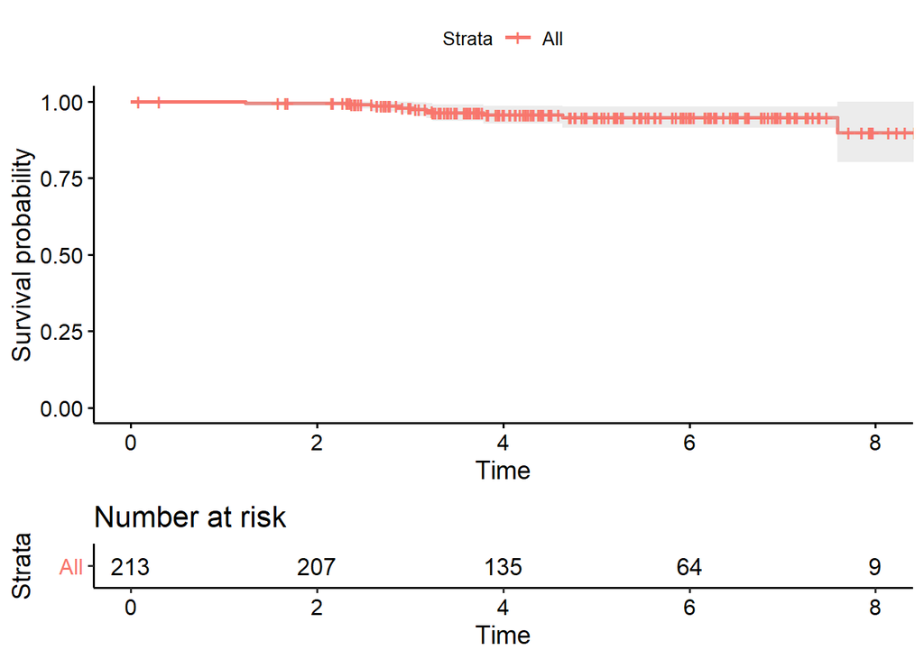

```r
ggsurvplot(kaplan,conf.int = TRUE, risk.table = TRUE, pval = TRUE, data = ap)
```

```r
kaplan2 <- survfit(Surv(survie, statut) ~ type_chimio, data = ap)
kaplan2
```

Call: survfit(formula = Surv(survie, statut) ~ type_chimio, data = ap)

22 observations deleted due to missingness n events median 0.95LCL 0.95UCL type_chimio=1 43 7 NA NA NA type_chimio=2 148 3 NA NA NA

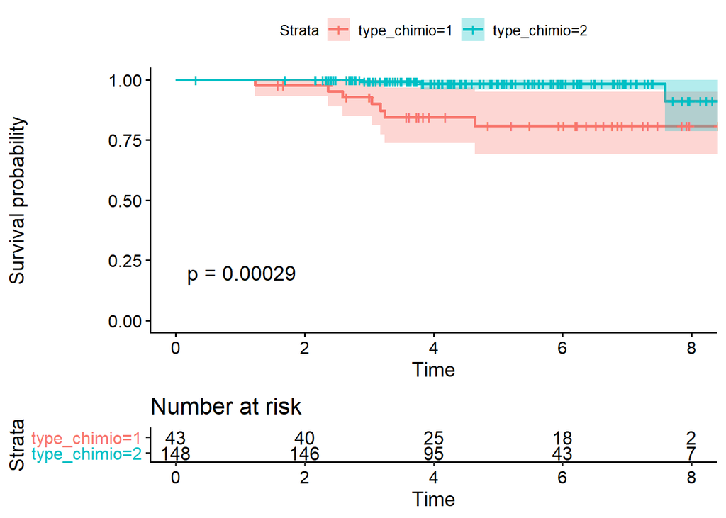

```r
ggsurvplot(kaplan2, conf.int = TRUE, risk.table = TRUE, pval = TRUE, data = ap)
```

##3.2 Courbe de Kaplan néoadj

```r
neo<-ap %>%
      filter(type_chimio==1)

neo$survie<-as.numeric(difftime(neo$date_derniere_nouvelles, neo$date_diag, unit="weeks"))/52.25

kaplan3 <- survfit(Surv(survie, statut) ~1, data = neo)
kaplan3
```

Call: survfit(formula = Surv(survie, statut) ~ 1, data = neo)

n events median 0.95LCL 0.95UCL 43 7 NA NA NA

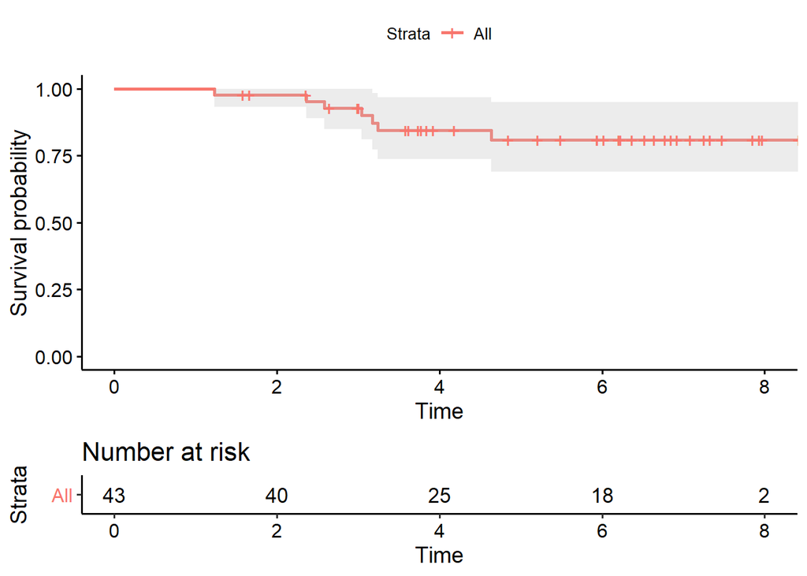

```r
ggsurvplot(kaplan3, conf.int = TRUE, risk.table = TRUE, pval = TRUE, data = neo)
```

##3.3 Courbe de Kaplan adj

```r
adj<-ap %>%
      filter(type_chimio==2)

adj$survie<-as.numeric(difftime(adj$date_derniere_nouvelles, adj$date_diag, unit="weeks"))/52.25
kaplan4 <- survfit(Surv(survie, statut) ~ 1, data =adj)
kaplan4
```

Call: survfit(formula = Surv(survie, statut) ~ 1, data = adj)

n events median 0.95LCL 0.95UCL 148 3 NA NA NA

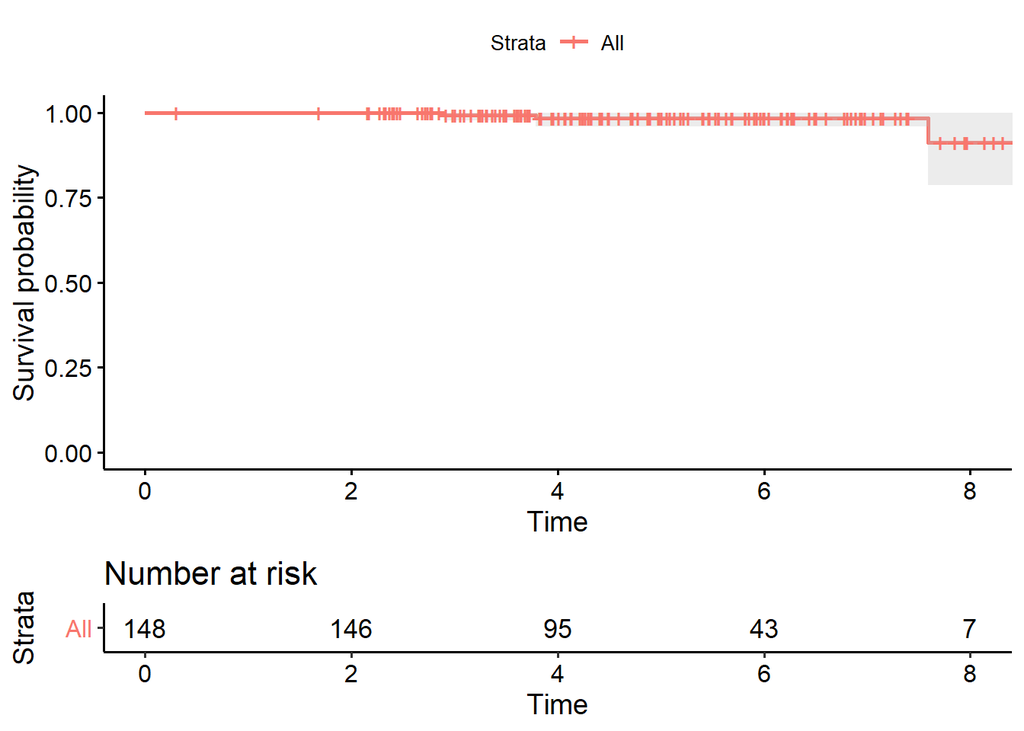

```r
ggsurvplot(kaplan4, conf.int = TRUE, risk.table = TRUE, pval = TRUE, data = adj)
```